# Ford GoBike System Data

## Dataset Overview

This data set includes information about individual rides made in a bike-sharing system covering the greater San Francisco Bay area.

## Investigation

1 - What day is the service used the most?

2 - What is the most common age?

3 - How long does the average trip take?

4 - what are the famous start station?

5 - What is rush hours?

6 - What day is the service used the most?

```python
# load important libraries
import numpy as np
import pandas as pd
import matplotlib.pyplot as plt
import seaborn as sb
%matplotlib inline
sb.set()
```

```python
# load data
df = pd.read_csv('201902-fordgobike-tripdata.csv')
```

```python
df.head()
```

|  | duration_sec | start_time | end_time | start_station_id | start_station_name | start_station_latitude | start_station_longitude | end_station_id | end_station_name | end_station_latitude | end_station_longitude | bike_id | user_type | member_birth_year | member_gender | bike_share_for_all_trip |
| --- | --- | --- | --- | --- | --- | --- | --- | --- | --- | --- | --- | --- | --- | --- | --- | --- |
| 0 | 52185 | 2019-02-28 17:32:10.1450 | 2019-03-01 08:01:55.9750 | 21.0 | Montgomery St BART Station (Market St at 2nd St) | 37.789625 | -122.400811 | 13.0 | Commercial St at Montgomery St | 37.794231 | -122.402923 | 4902 | Customer | 1984.0 | Male | No |
| 1 | 42521 | 2019-02-28 18:53:21.7890 | 2019-03-01 06:42:03.0560 | 23.0 | The Embarcadero at Steuart St | 37.791464 | -122.391034 | 81.0 | Berry St at 4th St | 37.775880 | -122.393170 | 2535 | Customer | NaN | NaN | No |
| 2 | 61854 | 2019-02-28 12:13:13.2180 | 2019-03-01 05:24:08.1460 | 86.0 | Market St at Dolores St | 37.769305 | -122.426826 | 3.0 | Powell St BART Station (Market St at 4th St) | 37.786375 | -122.404904 | 5905 | Customer | 1972.0 | Male | No |
| 3 | 36490 | 2019-02-28 17:54:26.0100 | 2019-03-01 04:02:36.8420 | 375.0 | Grove St at Masonic Ave | 37.774836 | -122.446546 | 70.0 | Central Ave at Fell St | 37.773311 | -122.444293 | 6638 | Subscriber | 1989.0 | Other | No |
| 4 | 1585 | 2019-02-28 23:54:18.5490 | 2019-03-01 00:20:44.0740 | 7.0 | Frank H Ogawa Plaza | 37.804562 | -122.271738 | 222.0 | 10th Ave at E 15th St | 37.792714 | -122.248780 | 4898 | Subscriber | 1974.0 | Male | Yes |

```python
# explore shape
df.shape
```

```
(183412, 16)
```

```python
# explore dtype
df.info()
```

```
<class 'pandas.core.frame.DataFrame'>
RangeIndex: 183412 entries, 0 to 183411
Data columns (total 16 columns):
 #   Column                   Non-Null Count   Dtype
---  ------                   --------------   -----
 0   duration_sec             183412 non-null  int64
 1   start_time               183412 non-null  object
 2   end_time                 183412 non-null  object
 3   start_station_id         183215 non-null  float64
 4   start_station_name       183215 non-null  object
 5   start_station_latitude   183412 non-null  float64
 6   start_station_longitude  183412 non-null  float64
 7   end_station_id           183215 non-null  float64
 8   end_station_name         183215 non-null  object
 9   end_station_latitude     183412 non-null  float64
 10  end_station_longitude    183412 non-null  float64
 11  bike_id                  183412 non-null  int64
 12  user_type                183412 non-null  object
 13  member_birth_year        175147 non-null  float64
 14  member_gender            175147 non-null  object
 15  bike_share_for_all_trip  183412 non-null  object
dtypes: float64(7), int64(2), object(7)
memory usage: 22.4+ MB
```

```
   there is Some columns have incorrect data types.
```

```python
df.describe()
```

|  | duration_sec | start_station_id | start_station_latitude | start_station_longitude | end_station_id | end_station_latitude | end_station_longitude | bike_id | member_birth_year |
| --- | --- | --- | --- | --- | --- | --- | --- | --- | --- |
| count | 183412.000000 | 183215.000000 | 183412.000000 | 183412.000000 | 183215.000000 | 183412.000000 | 183412.000000 | 183412.000000 | 175147.000000 |
| mean | 726.078435 | 138.590427 | 37.771223 | -122.352664 | 136.249123 | 37.771427 | -122.352250 | 4472.906375 | 1984.806437 |
| std | 1794.389780 | 111.778864 | 0.099581 | 0.117097 | 111.515131 | 0.099490 | 0.116673 | 1664.383394 | 10.116689 |
| min | 61.000000 | 3.000000 | 37.317298 | -122.453704 | 3.000000 | 37.317298 | -122.453704 | 11.000000 | 1878.000000 |
| 25% | 325.000000 | 47.000000 | 37.770083 | -122.412408 | 44.000000 | 37.770407 | -122.411726 | 3777.000000 | 1980.000000 |
| 50% | 514.000000 | 104.000000 | 37.780760 | -122.398285 | 100.000000 | 37.781010 | -122.398279 | 4958.000000 | 1987.000000 |
| 75% | 796.000000 | 239.000000 | 37.797280 | -122.286533 | 235.000000 | 37.797320 | -122.288045 | 5502.000000 | 1992.000000 |
| max | 85444.000000 | 398.000000 | 37.880222 | -121.874119 | 398.000000 | 37.880222 | -121.874119 | 6645.000000 | 2001.000000 |

# Data cleaning

```
    there are people born in 1878, it does not make sense ,  there is nobody can ride a bike more than 100-year-old
```

```python
# check if there is duplicate row
df.duplicated().sum()
```

```
0
```

```
     no duplicated row
```

```python
df.isnull().sum()
```

```
duration_sec                  0
start_time                    0
end_time                      0
start_station_id            197
start_station_name          197
start_station_latitude        0
start_station_longitude       0
end_station_id              197
end_station_name            197
end_station_latitude          0
end_station_longitude         0
bike_id                       0
user_type                     0
member_birth_year          8265
member_gender              8265
bike_share_for_all_trip       0
dtype: int64
```

```python
# drop row with null value
df.dropna( axis = 0 , inplace = True)
```

```python
# check agin
df.isnull().sum()
```

```
duration_sec               0
start_time                 0
end_time                   0
start_station_id           0
start_station_name         0
start_station_latitude     0
start_station_longitude    0
end_station_id             0
end_station_name           0
end_station_latitude       0
end_station_longitude      0
bike_id                    0
user_type                  0
member_birth_year          0
member_gender              0
bike_share_for_all_trip    0
dtype: int64
```

```python
df.shape
```

```
(174952, 16)
```

```python
# drop people more than 100 years old
df = df.drop(df[df.member_birth_year < 1918].index )
```

```python
df.shape
```

```
(174880, 16)
```

```python
# recorrect dtype
df['start_time'] = pd.to_datetime(df['start_time'])
df['end_time'] = pd.to_datetime(df['end_time'])
```

```python
# create a column of age
df['age'] = 2018 - df.member_birth_year
df['age'] = df['age'].astype(int)
```

```python
# create a column of duration in minutes
df['duration_min'] = df.duration_sec // 60
```

```python
# create a column of hour & day
df=df.assign(hour=pd.to_datetime(df['start_time']).dt.strftime("%H"), day=pd.to_datetime(df['start_time']).dt.date)
df['hour'] = df['hour'].astype(int)
```

```python
# create a column of day name
df['day_of_week'] = df['start_time'].dt.day_name()
```

```
we want to know if the day is weekday or weekend
weekday :- ( Monday , Tuesday , Wednesday , Thursday , Friday )
weekend :- ( Saturday , Sunday )
```

```python
# create a column that contain if the day is weekday or weekend
weekday = ( 'Monday' , 'Tuesday' , 'Wednesday' , 'Thursday' , 'Friday' )
weekend = ( 'Saturday' , 'Sunday' )

def type_day(day) :

    if day in weekday :
        type_of_day = 'weekday'

    else :
        type_of_day = 'weekend'

    return type_of_day
```

```python
df['type_of_day'] = df['day_of_week'].apply(type_day)
```

```python
# drop columns
df.drop(['start_station_latitude', 'start_station_longitude' , 'end_station_latitude' , 'end_station_longitude' ,'member_birth_year' , 'bike_id' , 'duration_sec'] , axis = 1 ,inplace = True)
```

```python
# save data after cleaning to csv file
df.to_csv('2019-02-fordgobike-clean.csv')
```

```python
df.head()
```

|  | start_time | end_time | start_station_id | start_station_name | end_station_id | end_station_name | user_type | member_gender | bike_share_for_all_trip | age | duration_min | hour | day | day_of_week | type_of_day |
| --- | --- | --- | --- | --- | --- | --- | --- | --- | --- | --- | --- | --- | --- | --- | --- |
| 0 | 2019-02-28 17:32:10.145 | 2019-03-01 08:01:55.975 | 21.0 | Montgomery St BART Station (Market St at 2nd St) | 13.0 | Commercial St at Montgomery St | Customer | Male | No | 34 | 869 | 17 | 2019-02-28 | Thursday | weekday |
| 2 | 2019-02-28 12:13:13.218 | 2019-03-01 05:24:08.146 | 86.0 | Market St at Dolores St | 3.0 | Powell St BART Station (Market St at 4th St) | Customer | Male | No | 46 | 1030 | 12 | 2019-02-28 | Thursday | weekday |
| 3 | 2019-02-28 17:54:26.010 | 2019-03-01 04:02:36.842 | 375.0 | Grove St at Masonic Ave | 70.0 | Central Ave at Fell St | Subscriber | Other | No | 29 | 608 | 17 | 2019-02-28 | Thursday | weekday |
| 4 | 2019-02-28 23:54:18.549 | 2019-03-01 00:20:44.074 | 7.0 | Frank H Ogawa Plaza | 222.0 | 10th Ave at E 15th St | Subscriber | Male | Yes | 44 | 26 | 23 | 2019-02-28 | Thursday | weekday |
| 5 | 2019-02-28 23:49:58.632 | 2019-03-01 00:19:51.760 | 93.0 | 4th St at Mission Bay Blvd S | 323.0 | Broadway at Kearny | Subscriber | Male | No | 59 | 29 | 23 | 2019-02-28 | Thursday | weekday |

# Exploratory Data Analysis

### Univariate Exploration

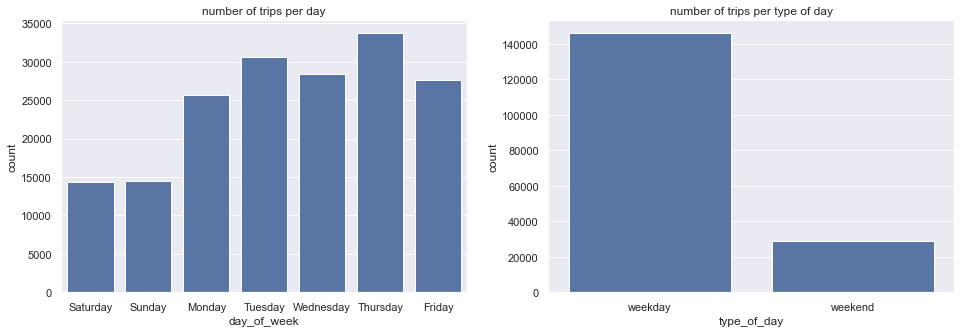

```python
# frequency of trips across the week
plt.figure(figsize = [16, 5])
base_color = sb.color_palette()[0]     # to make chart one color
days = (  'Saturday' , 'Sunday' , 'Monday' , 'Tuesday' , 'Wednesday' , 'Thursday' , 'Friday' )


plt.subplot(1, 2, 1)
sb.countplot(data= df , x='day_of_week' , color=base_color , order = days)
plt.title('number of trips per day')


plt.subplot(1, 2, 2)
sb.countplot(data= df , x='type_of_day' , color=base_color)
plt.title('number of trips per type of day');
```

```
 number of trips increase across the weekdays , while at the weekends number of trips decrease
```

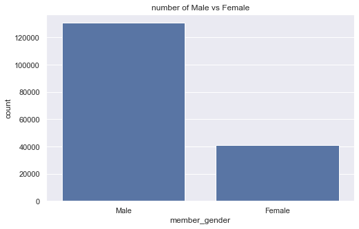

```python
plt.figure(figsize = [8, 5])
base_color = sb.color_palette()[0]
gender = ( 'Male' , 'Female' )

sb.countplot(data= df , x='member_gender' , color=base_color , order = gender )
plt.title('number of Male vs Female') ;
```

```
The graph shows that the number of males is about three times more than females
```

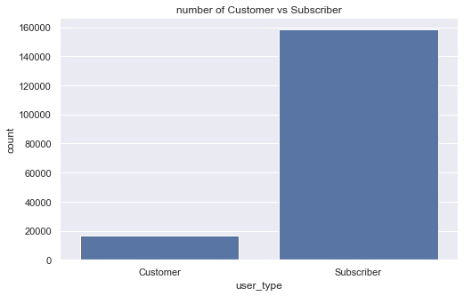

```python
plt.figure(figsize = [8, 5])
base_color = sb.color_palette()[0]

sb.countplot(data= df , x='user_type' , color=base_color )
plt.title('number of Customer vs Subscriber') ;
```

[output not shown]

### What is the most common age?

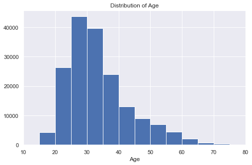

```python
# distribution of age
plt.figure(figsize = [8, 5])
bins_x = np.arange(10, df['age'].max()+5, 5)

plt.hist( data= df , x='age', bins = bins_x  )
plt.title('Distribution of Age')
plt.xlabel('Age')
plt.xlim((10,80)) ;
```

[output not shown]

```python
df.describe().T
```

|  | count | mean | std | min | 25% | 50% | 75% | max |
| --- | --- | --- | --- | --- | --- | --- | --- | --- |
| start_station_id | 174880.0 | 138.978528 | 111.636735 | 3.0 | 47.0 | 104.0 | 239.0 | 398.0 |
| end_station_id | 174880.0 | 136.602573 | 111.332869 | 3.0 | 44.0 | 101.0 | 238.0 | 398.0 |
| age | 174880.0 | 33.162043 | 9.974001 | 17.0 | 26.0 | 31.0 | 38.0 | 98.0 |
| duration_min | 174880.0 | 11.241783 | 27.376440 | 1.0 | 5.0 | 8.0 | 13.0 | 1409.0 |
| hour | 174880.0 | 13.456181 | 4.734400 | 0.0 | 9.0 | 14.0 | 17.0 | 23.0 |

### How long does the average trip take?

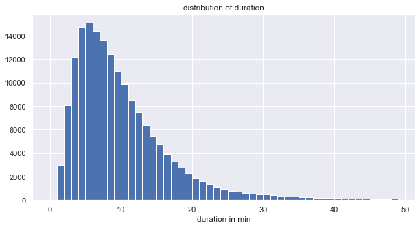

```python
# distribution of duration
plt.figure(figsize = [10, 5])
bins_x = np.arange(0,50, 1)

plt.hist( data= df , x='duration_min', bins = bins_x  )
plt.title('distribution of duration')
plt.xlabel('duration in min') ;
```

```
the most ride take between 3 and 20 min
```

### what are the famous start station?

```python
most_10_station = df['start_station_name'].value_counts().head(10).index
```

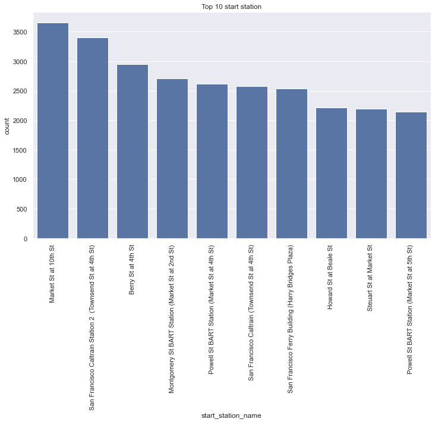

```python
# Frequency of top start stations
plt.figure(figsize = [12, 7])
base_color = sb.color_palette()[0]
plt.xticks(rotation=90)

sb.countplot(data= df , x='start_station_name' , color=base_color , order = most_10_station )
plt.title('Top 10 start station') ;
```

### What is rush hours?

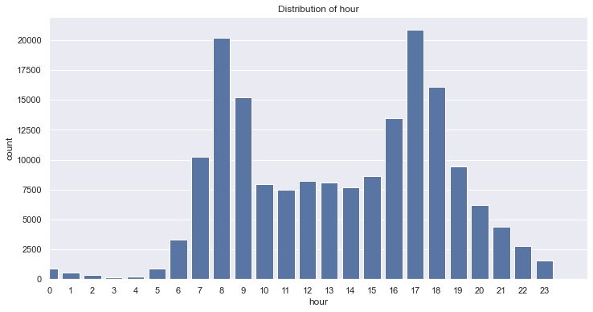

```python
# distribution of hour
plt.figure(figsize = [12, 6])
bins_x = np.arange(0, df['hour'].max()+1, 1)

sb.countplot( data= df , x='hour' , color=base_color )
plt.title('Distribution of hour')
plt.xlabel('hour')
plt.xlim((0,25)) ;
```

```
Rush hour between (7am : 9am) and (4pm : 6pm)
```

# Bivariate Exploration

#### relationship between two variables

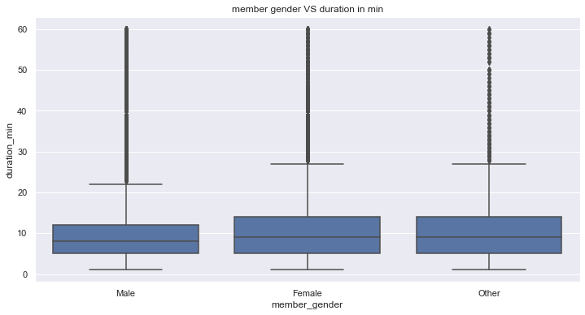

```python
# distribution of duration in min. Vs. gender:
df_duration = df.query( " duration_min <= 60")
plt.figure(figsize = [12, 6])
base_color = sb.color_palette()[0]
sb.boxplot(data=df_duration , x='member_gender' , y='duration_min' , color=base_color)
plt.title('member gender VS duration in min') ;
```

the trip duration is almost the same for all genders

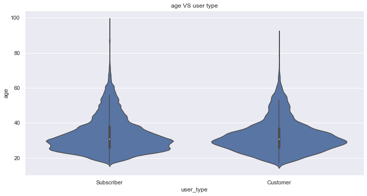

```python
# distribution of age Vs gender user type
df_duration = df.query( " duration_min <= 60")
plt.figure(figsize = [12, 6])
base_color = sb.color_palette()[0]
sb.violinplot(data=df_duration , x='user_type' , y='age' , color=base_color)
plt.title('age VS user type') ;
```

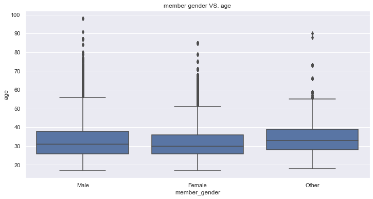

```python
# distribution of age Vs. gender:
plt.figure(figsize = [12, 6])
base_color = sb.color_palette()[0]
sb.boxplot(data=df_duration , x='member_gender' , y='age' , color=base_color)
plt.title('member gender VS. age') ;
```

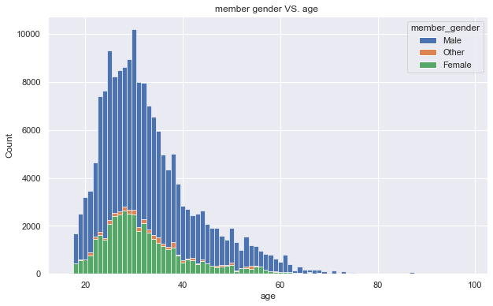

```python
# distribution of age Vs. gender:
plt.figure(figsize = [10, 6])

sb.histplot(data=df, x='age', stat='count', discrete=True, hue='member_gender', multiple='stack', alpha = 1)
plt.title('member gender VS. age ') ;
```

```
distribution of age Vs gender is nearly the same
```

### What day is the service used the most?

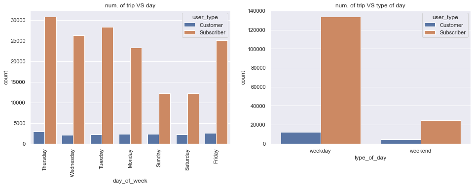

```python
# Plotting numberof trip Vs weekdays Vs the type of day:

plt.figure(figsize = [16, 5])

plt.subplot(1, 2, 1)
sb.countplot(data=df , x='day_of_week', hue='user_type')
plt.title('num. of trip VS day')
plt.xticks(rotation=90)

plt.subplot(1, 2, 2)
sb.countplot(data=df , x='type_of_day', hue='user_type')
plt.title('num. of trip VS type of day') ;
```

```
Number of customer is the same across all of weekday , but slightly less in the weekend
Number of subscriber is greatly reduced in the weekend
```

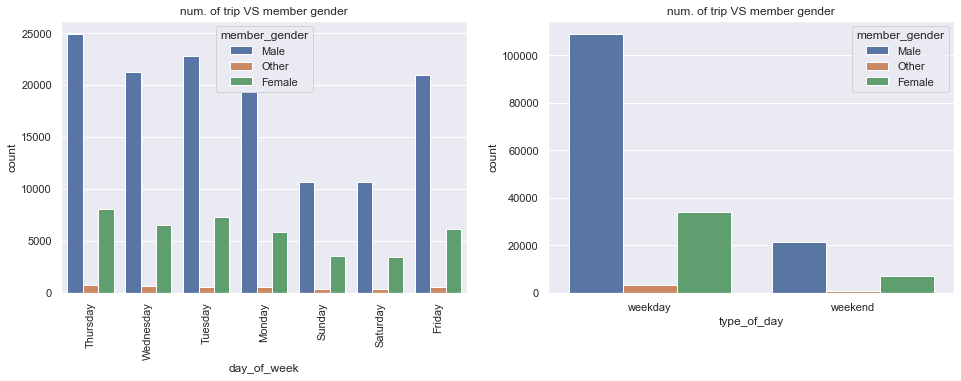

```python
# Plotting number of trip Vs weekdays Vs member_gender:

plt.figure(figsize = [16, 5])

plt.subplot(1, 2, 1)
sb.countplot(data=df , x='day_of_week', hue='member_gender')
plt.title('num. of trip VS member gender')
plt.xticks(rotation=90)

plt.subplot(1, 2, 2)
sb.countplot(data=df , x='type_of_day', hue='member_gender')
plt.title('num. of trip VS member gender') ;
```

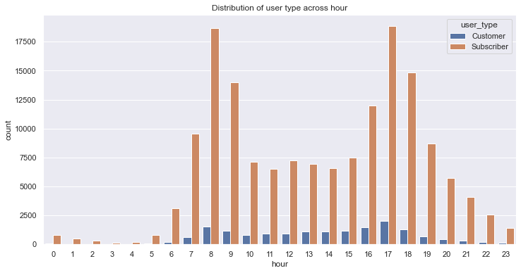

```python
# distribution of hour vs user type
plt.figure(figsize = [12, 6])

sb.countplot( data= df , x='hour' , hue = 'user_type')
plt.title('Distribution of user type across hour')
plt.xlabel('hour') ;
```

```
subscriber more likely to use Bike in rush hour
customer slightly more to use Bike in rush hour
```

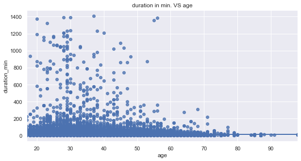

```python
# plotting duration in min. VS age
plt.figure(figsize = [10,5])
sb.regplot(data = df , x = 'age', y = 'duration_min');
plt.title('duration in min. VS age') ;
```

```
There is no relationship between age and duration in min.
```

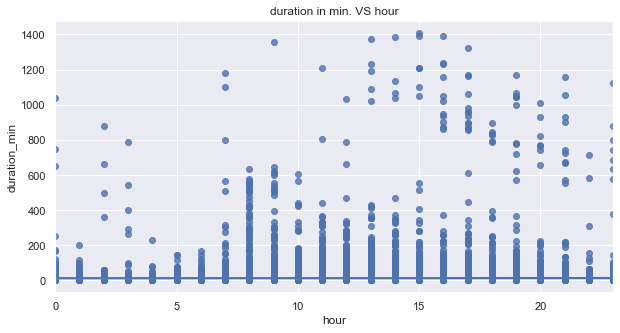

```python
# plotting duration in min. VS hour
plt.figure(figsize = [10, 5])
sb.regplot(data = df , x = 'hour', y = 'duration_min');
plt.title('duration in min. VS hour') ;
```

There is no relationship between hour and duration in min.

# Multivariate Exploration

In this section, find relationships between three or more variables .

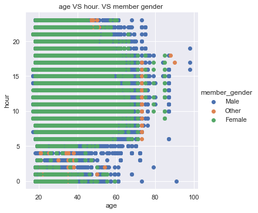

```python
# age VS hour. VS member gender
g = sb.FacetGrid(data = df, hue = 'member_gender', size = 5)
g.map(plt.scatter, 'age', 'hour')
g.add_legend()
plt.title('age VS hour. VS member gender ') ;
```

There is no relationship between hour , age and gender .

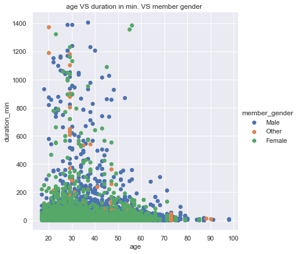

```python
# age VS duration in min. VS member gender
g = sb.FacetGrid(data = df, hue = 'member_gender', size = 6)
g.map(plt.scatter, 'age', 'duration_min')
g.add_legend()
plt.title('age VS duration in min. VS member gender ') ;
```

There is no relationship between duration in min. , age and gender .

```
''
```

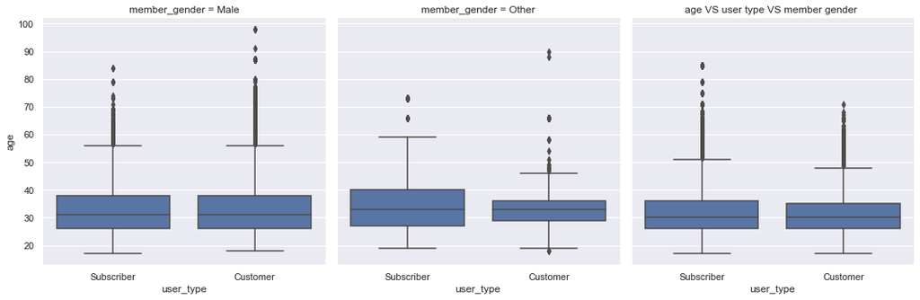

```python
# age VS user type VS member gender
g = sb.FacetGrid(data = df, col = 'member_gender', size = 5)
g.map(sb.boxplot, 'user_type', 'age')
plt.title('age VS user type VS member gender ')
;
```

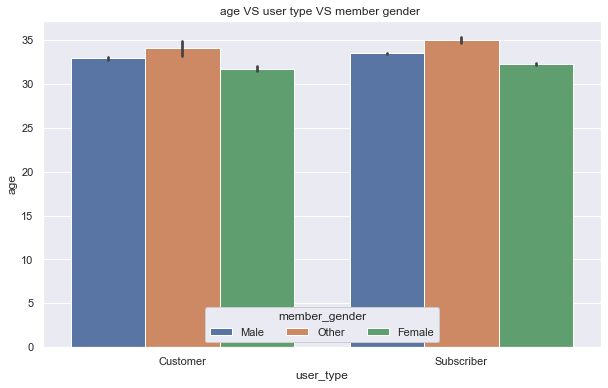

```python
plt.figure(figsize = [10,6])

ax = sb.barplot(data = df, x = 'user_type', y = 'age', hue = 'member_gender')
ax.legend(loc = 8, ncol = 3, framealpha = 1, title = 'member_gender')
plt.title('age VS user type VS member gender ') ;
```

```
distribution is nearly the same
```

# Findings

2-number of male much more than female.

5-the most ride take between 3 and 20 min

6-Rush hour between (7am : 9am) and (4pm : 6pm)

```python
!jupyter nbconvert ford_gobike_presentation.ipynb --to slides --post serve --no-input --no-prompt
```